# Assignment 04

Adwait Kalsekar

2023-10-07

# Dataset Information

The dataset chosen for this assignment consists of the House Price Index for the State of New Jersey over the last 50 years calculated quarterly.

Looking at the time series data it can also be inferred that there has been a visible trend in the growth of HPI over the last 50 years. The HPI has increased exponentially since the year 1975 to the year 2023.

Looking at the time series data, certain forecasting models applied have predicted similar future data points that account for the existing trend and seasonality.

# Exploring the Dataset

## Loading the Dataset and Converting to Time Series

```r
# Loading Libraries
library(fpp)
library(fpp2)
library(TTR)

# Reading Data from CSV File
df = read.csv("NJ_HPI.csv")
str(df)
```

```
## 'data.frame':    194 obs. of  2 variables:
##  $ DATE  : chr  "1975-01-01" "1975-04-01" "1975-07-01" "1975-10-01" ...
##  $ HPI.NJ: num  64.3 59.3 60.1 62.8 62.8 ...
```

```r
# Converting DATE column to R Date Type
df$DATE <- as.Date(df$DATE)
str(df)
```

```
## 'data.frame':    194 obs. of  2 variables:
##  $ DATE  : Date, format: "1975-01-01" "1975-04-01" ...
##  $ HPI.NJ: num  64.3 59.3 60.1 62.8 62.8 ...
```

```r
df
```

```
##           DATE HPI.NJ
## 1   1975-01-01  64.32
## 2   1975-04-01  59.29
## 3   1975-07-01  60.10
## 4   1975-10-01  62.81
## 5   1976-01-01  62.79
## 6   1976-04-01  63.85
## 7   1976-07-01  65.88
## 8   1976-10-01  62.21
## 9   1977-01-01  65.12
## 10  1977-04-01  65.35
## 11  1977-07-01  67.42
## 12  1977-10-01  69.48
## 13  1978-01-01  71.16
## 14  1978-04-01  73.21
```

[output cut: 180 more lines]

```r
# Converting to Time Series data
df_ts = ts(df$HPI.NJ, start=c(1975, 1), end=c(2023, 2), frequency=4)
df_ts
```

```
##        Qtr1   Qtr2   Qtr3   Qtr4
## 1975  64.32  59.29  60.10  62.81
## 1976  62.79  63.85  65.88  62.21
## 1977  65.12  65.35  67.42  69.48
## 1978  71.16  73.21  76.36  79.63
## 1979  85.07  87.02  91.60  94.18
## 1980 100.00 101.55 100.79 103.72
## 1981 104.26 105.86 107.56 105.86
## 1982 105.37 108.91 109.14 109.62
## 1983 110.11 113.74 117.62 120.82
## 1984 123.83 130.15 134.91 138.18
## 1985 142.17 148.46 154.96 161.87
## 1986 167.97 178.06 189.18 199.06
## 1987 210.10 221.27 229.93 235.24
## 1988 240.37 246.40 247.15 246.30
```

[output cut: 35 more lines]

```r
# Attributes and Structure
attributes(df_ts)
```

```
## $tsp
## [1] 1975.00 2023.25    4.00
##
## $class
## [1] "ts"
```

```r
str(df_ts)
```

```
##  Time-Series [1:194] from 1975 to 2023: 64.3 59.3 60.1 62.8 62.8 ...
```

## Plotting and Observing the Auto Correlation Function

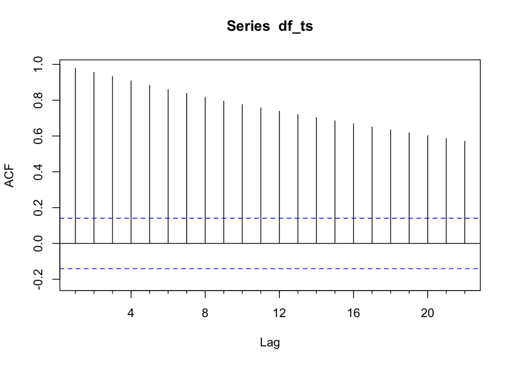

```r
# Plotting ACF
Acf(df_ts)
```

```r
summary(df_ts)
```

```
##    Min. 1st Qu.  Median    Mean 3rd Qu.    Max.
##   59.29  212.89  260.84  330.19  486.63  783.94
```

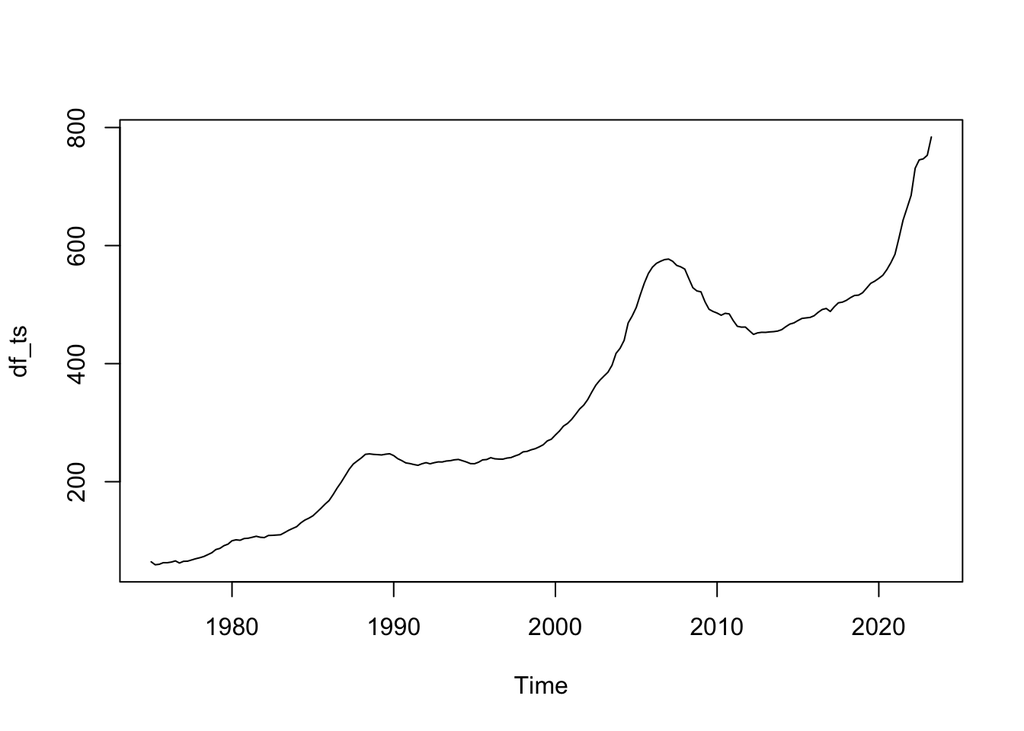

```r
plot(df_ts)
```

# Forecasting

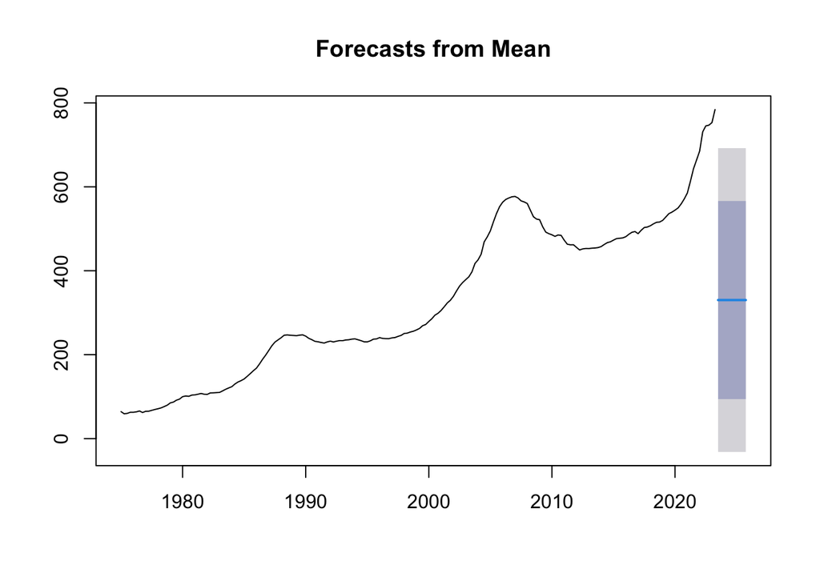

```r
# Mean Forecast
mean_forecast <- meanf(df_ts, 10)
plot(mean_forecast)
```

### Mean Forecast:

It produces visually inaccurate results as it calculates the mean of all the data points in the time series data.

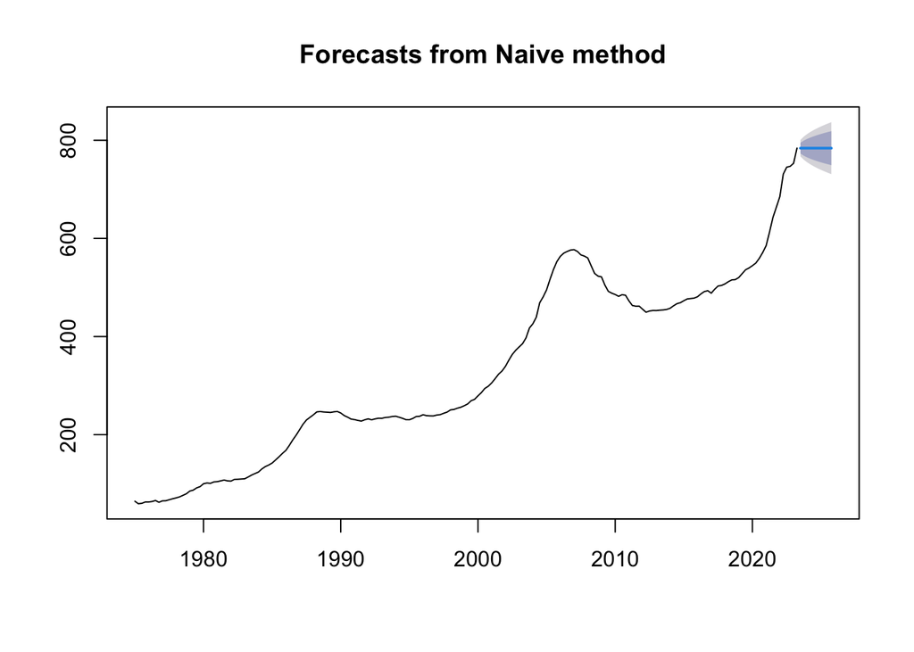

```r
# Naive
naive_forecast <- naive(df_ts, 10)
plot(naive_forecast)
```

### Naive Forecast:

It accounts only for the most recent data point and forecasts it for the next data points. It can be used for a small data set without any trend or seasonality forecasted for a small time period. In the time series data used in this assignment, the naive method provides inaccurate results.

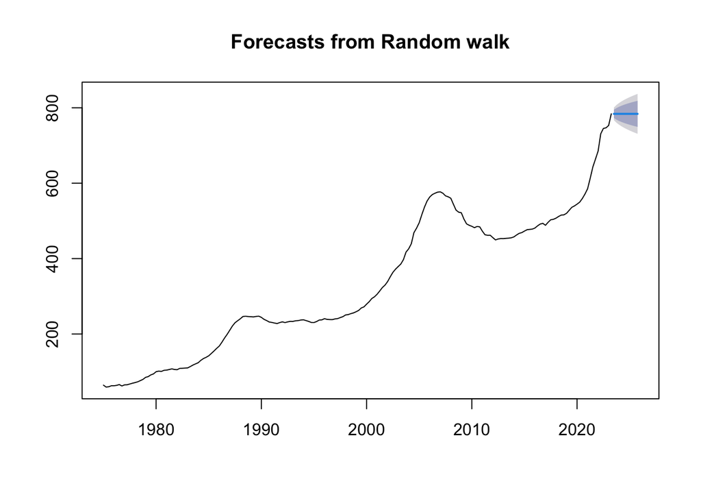

```r
# Random Walk
rwf_forecast <- rwf(df_ts, 10)
plot(rwf_forecast)
```

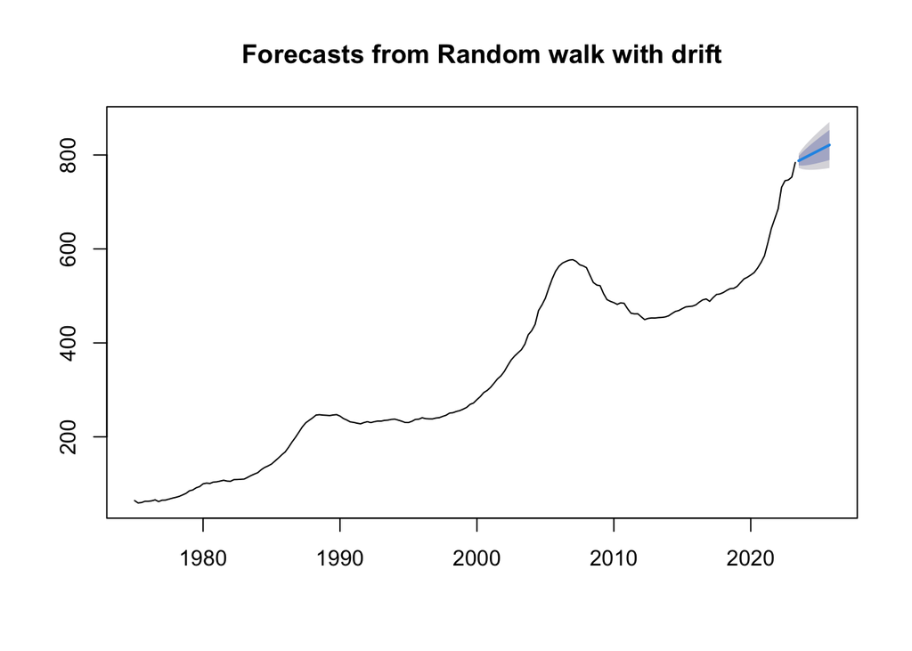

```r
# Random Walk with Drift
rwf_forecast <- rwf(df_ts, 10, drift=TRUE)
plot(rwf_forecast)
```

### Random walk with a drift: This model considers the most recent data point with a drift term and hence can provide good results for a short time period. In this case, it shows good results as it accounts for the growing trend.

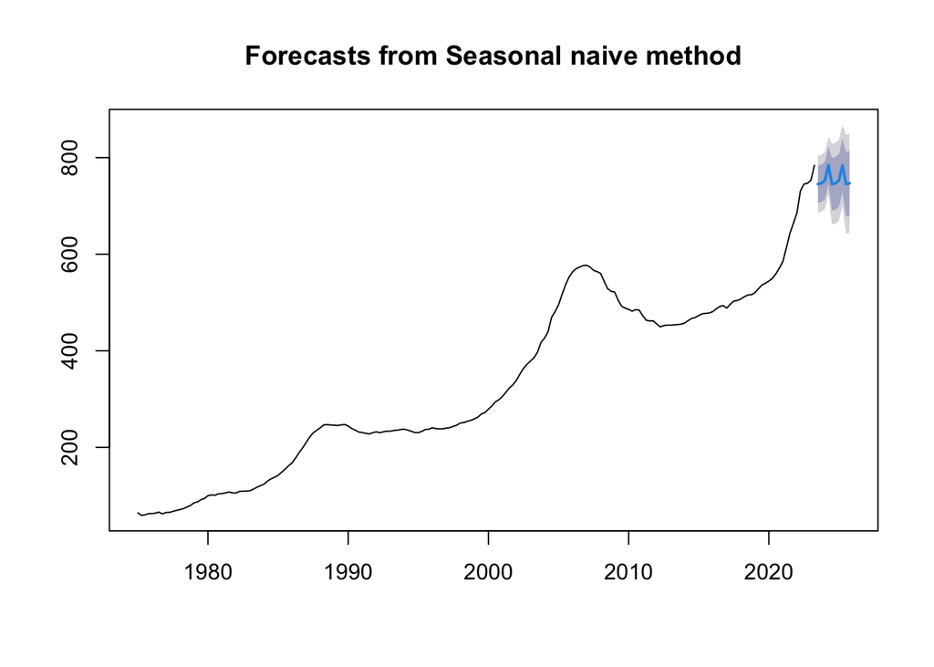

```r
# Seasonal Naive
snaive_forecast <- snaive(df_ts, 10)
plot(snaive_forecast)
```

### Seasonal Naive:

This model is perfect for a highly seasonal data without accounting for the trend and gives inaccurate results in this case.

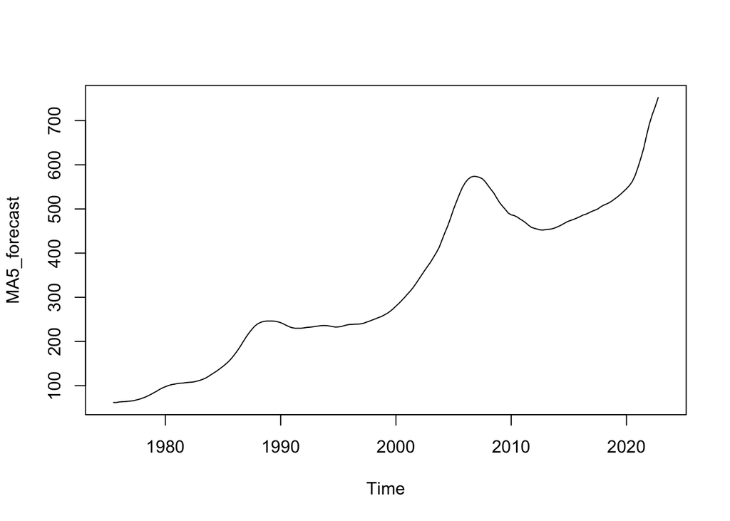

```r
# Moving Averages
MA5_forecast <- ma(df_ts,order=5)
plot(MA5_forecast)
```

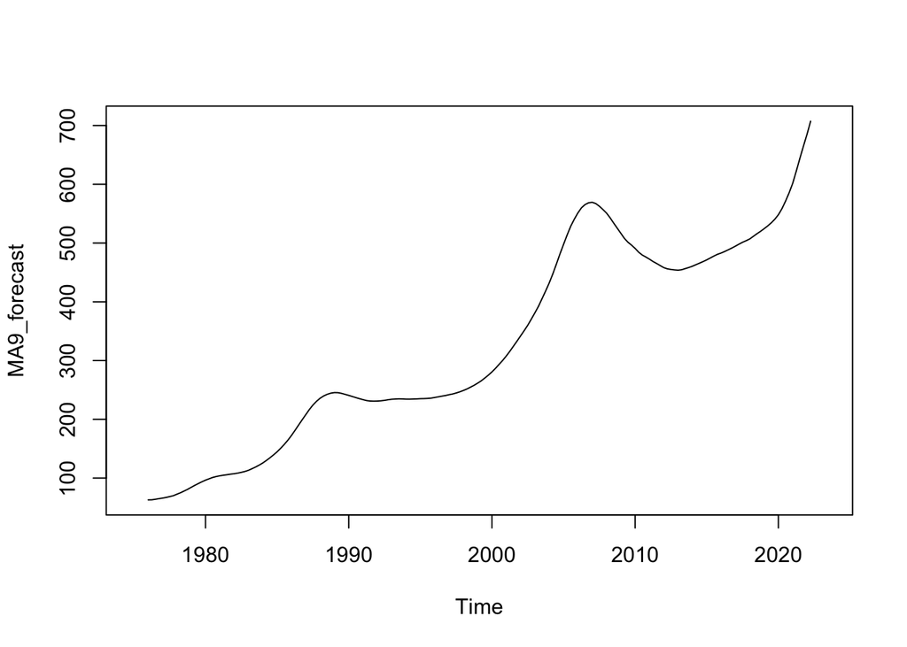

```r
MA9_forecast <- ma(df_ts,order=9)
plot(MA9_forecast)
```

## Exploring the Naive and Mean Forecasts

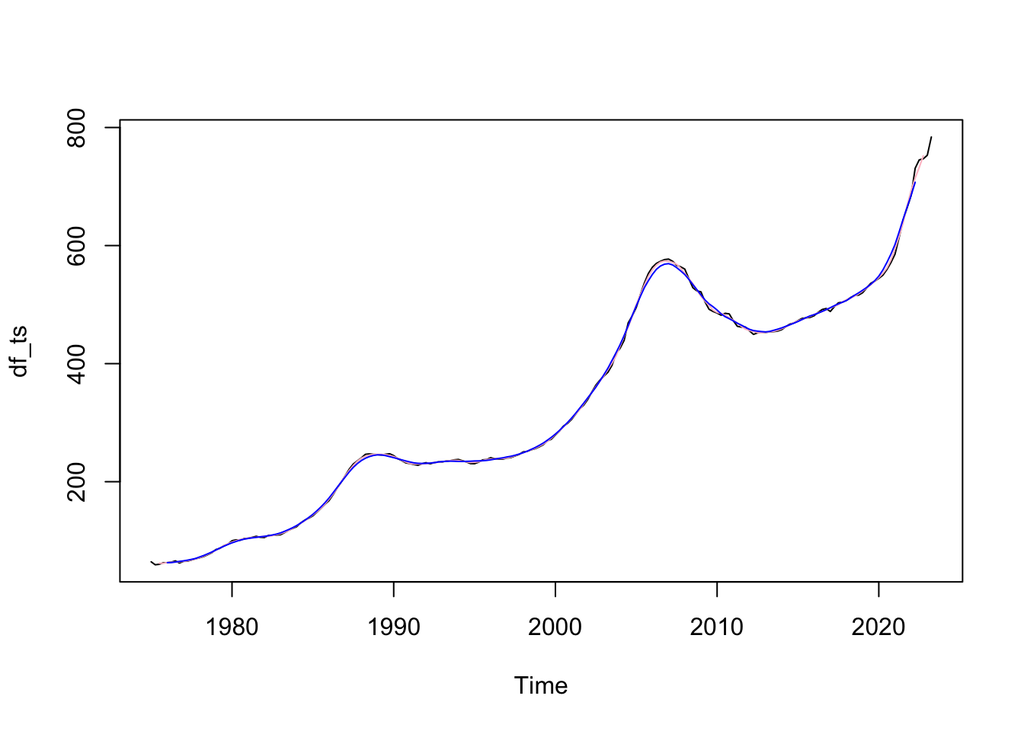

```r
# Visualising Moving Averages Separately
plot(df_ts)
lines(MA5_forecast,col="Pink")
lines(MA9_forecast,col="Blue")
```

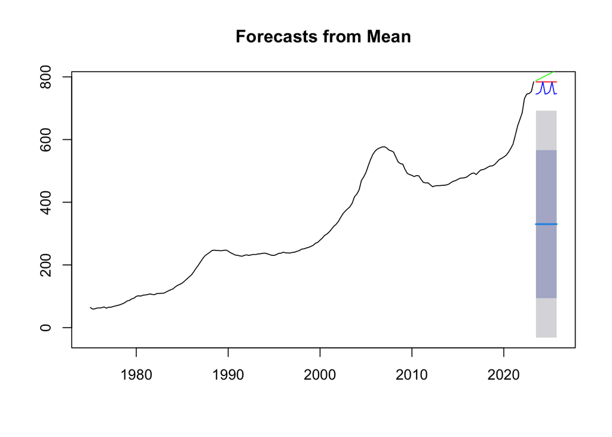

```r
# Comparing Various Visualisations
plot(mean_forecast)
lines(naive_forecast$mean,col="red")
lines(rwf_forecast$mean,col="green")
lines(snaive_forecast$mean,col="blue")
```

## Exponential Smoothing

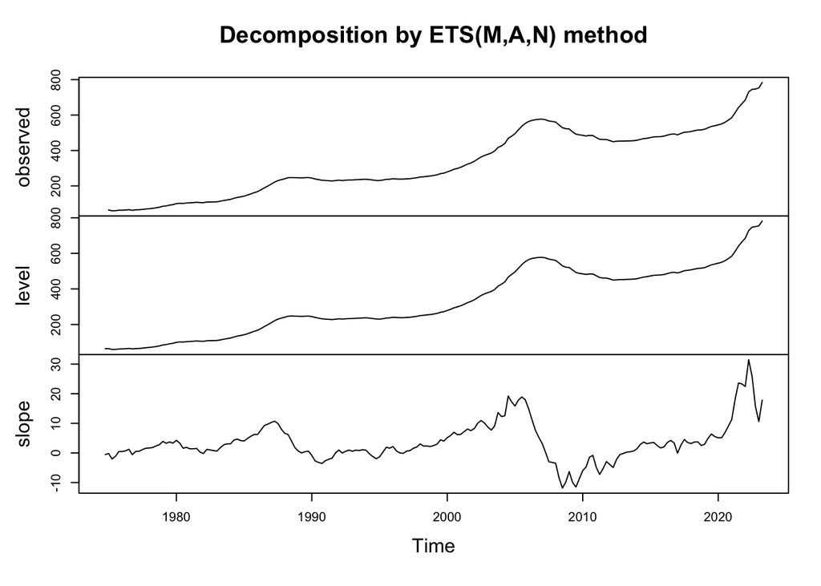

```r
# Exponential Smoothing
ets_model <- ets(df_ts)
plot(ets_model)
```

### ETS:

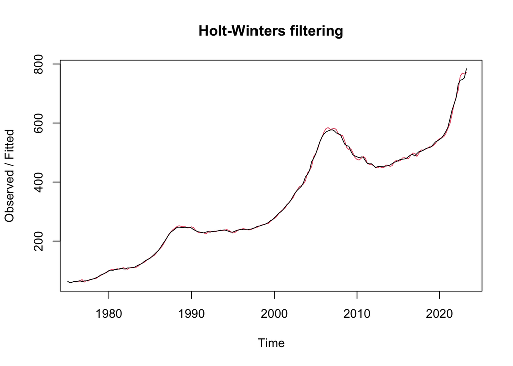

```r
# HoltWinters
HW <- HoltWinters(df_ts)
plot(HW)
```

```r
# Holt Winters with Different Beta and Gamma Values
SSE_Simple_1 <- HoltWinters(df_ts,beta=FALSE,gamma=FALSE)
attributes(SSE_Simple_1)
```

```
## $names
## [1] "fitted"       "x"            "alpha"        "beta"         "gamma"
## [6] "coefficients" "seasonal"     "SSE"          "call"
##
## $class
## [1] "HoltWinters"
```

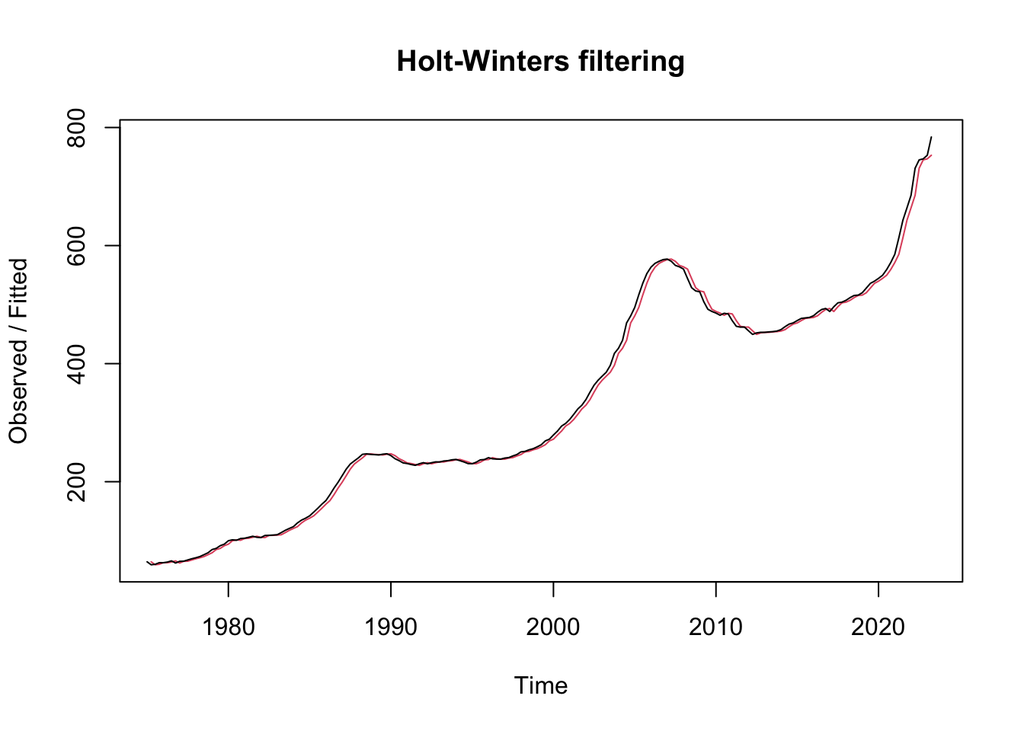

```r
plot(SSE_Simple_1)
```

```r
SSE_Simple_1$SSE
```

```
## [1] 14076.66
```

```r
SSE_Simple_2 <- HoltWinters(df_ts,beta=FALSE,gamma=TRUE)
attributes(SSE_Simple_2)
```

```
## $names
## [1] "fitted"       "x"            "alpha"        "beta"         "gamma"
## [6] "coefficients" "seasonal"     "SSE"          "call"
##
## $class
## [1] "HoltWinters"
```

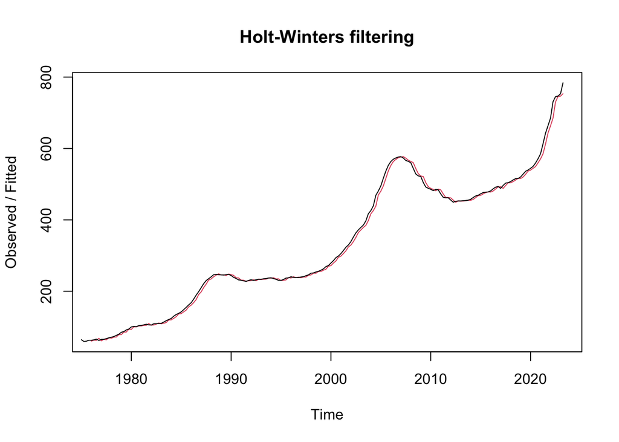

```r
plot(SSE_Simple_2)
```

```r
SSE_Simple_2$SSE
```

```
## [1] 14480.41
```

```r
SSE_Simple_3 <- HoltWinters(df_ts,beta=TRUE,gamma=FALSE)
attributes(SSE_Simple_3)
```

```
## $names
## [1] "fitted"       "x"            "alpha"        "beta"         "gamma"
## [6] "coefficients" "seasonal"     "SSE"          "call"
##
## $class
## [1] "HoltWinters"
```

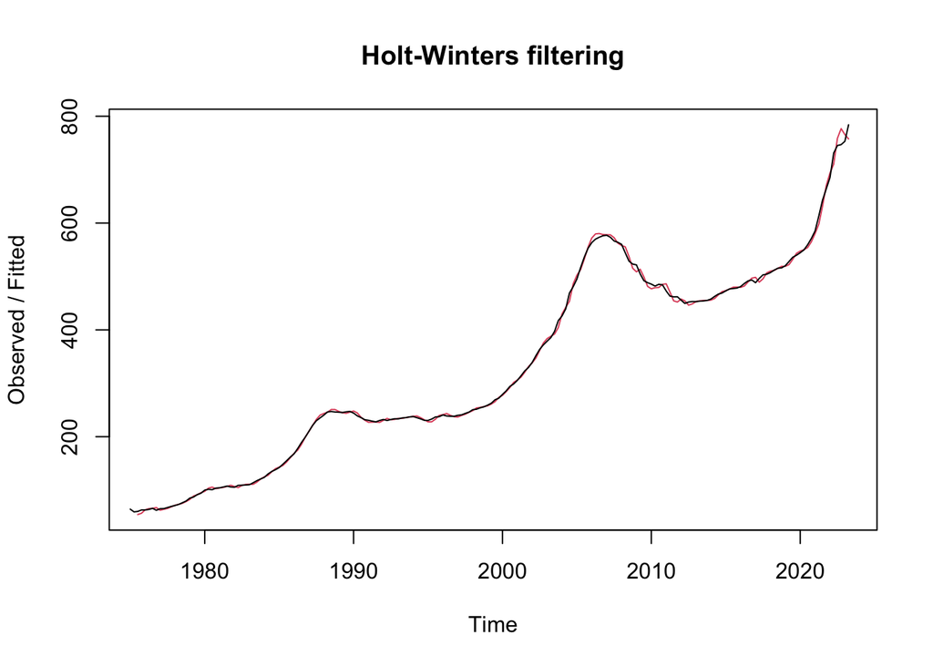

```r
plot(SSE_Simple_3)
```

```r
SSE_Simple_3$SSE
```

```
## [1] 6030.864
```

```r
SSE_Simple_4 <- HoltWinters(df_ts,beta=FALSE,gamma=FALSE)
attributes(SSE_Simple_4)
```

```
## $names
## [1] "fitted"       "x"            "alpha"        "beta"         "gamma"
## [6] "coefficients" "seasonal"     "SSE"          "call"
##
## $class
## [1] "HoltWinters"
```

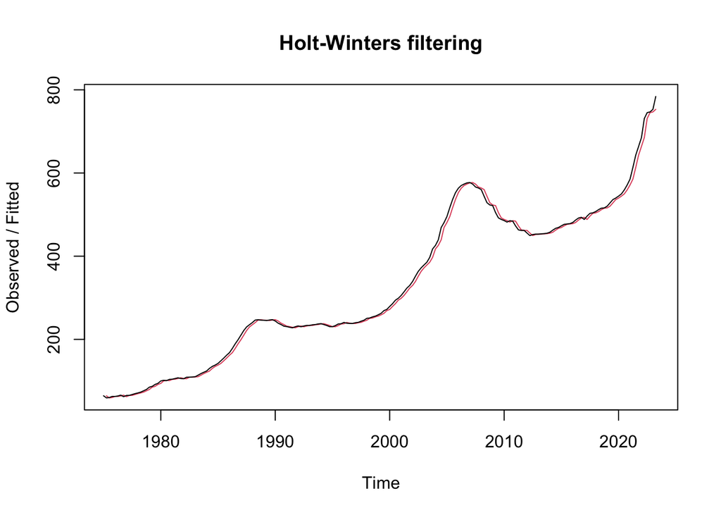

```r
plot(SSE_Simple_4)
```

```r
SSE_Simple_4$SSE
```

```
## [1] 14076.66
```

## Exploring the ETS and Holt Winters Models

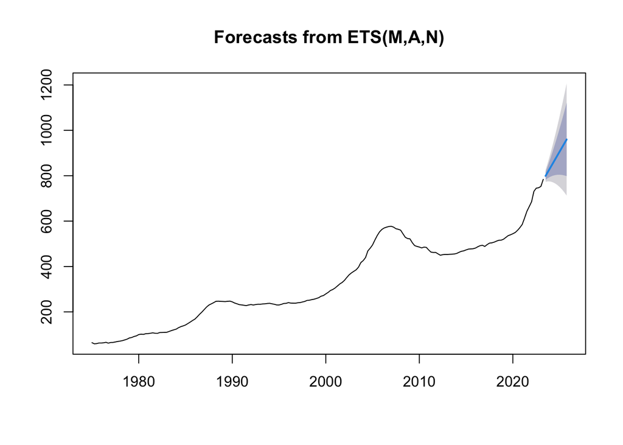

```r
# Forecast for ETS
ets_forecast <- forecast(ets_model, h=10)
plot(ets_forecast)
```

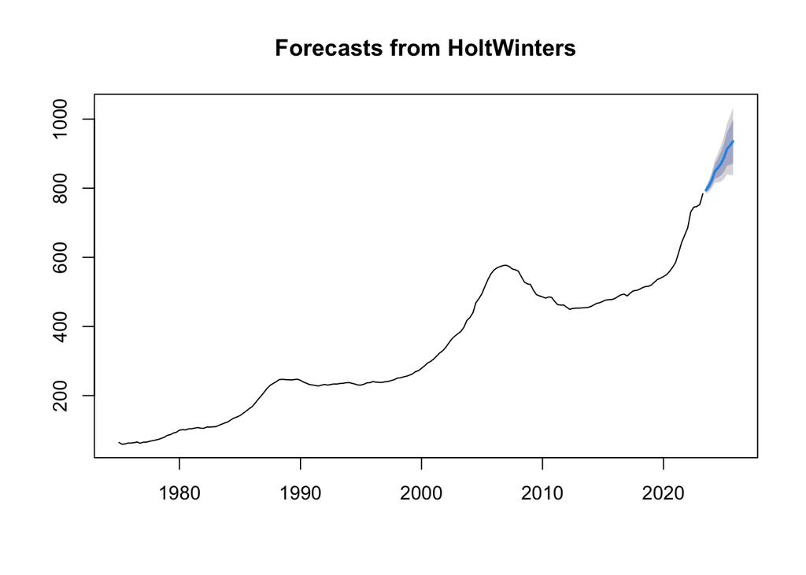

```r
HW_forecast <- forecast(HW, h=10)
plot(HW_forecast)
```

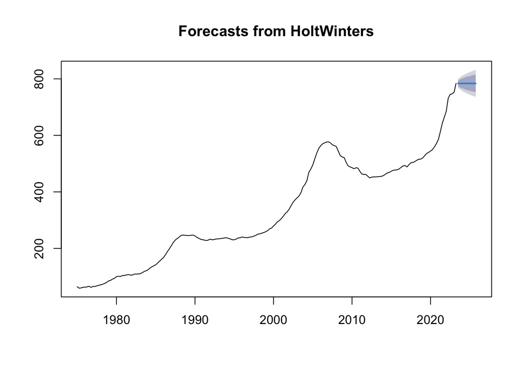

```r
SSE_Simple_forecast_1 <- forecast(SSE_Simple_1, h=10)
plot(SSE_Simple_forecast_1)
```

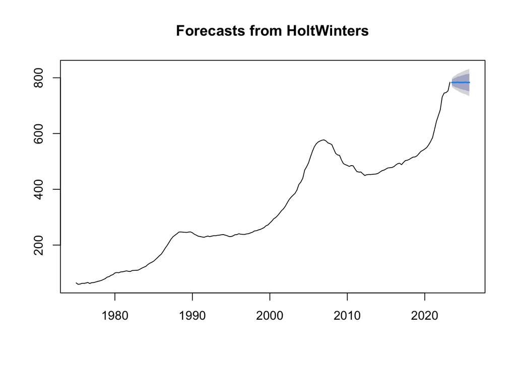

```r
SSE_Simple_forecast_2 <- forecast(SSE_Simple_2, h=10)
plot(SSE_Simple_forecast_2)
```

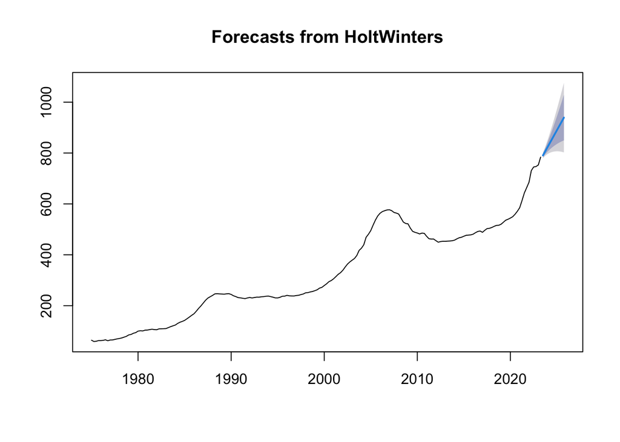

```r
SSE_Simple_forecast_3 <- forecast(SSE_Simple_3, h=10)
plot(SSE_Simple_forecast_3)
```

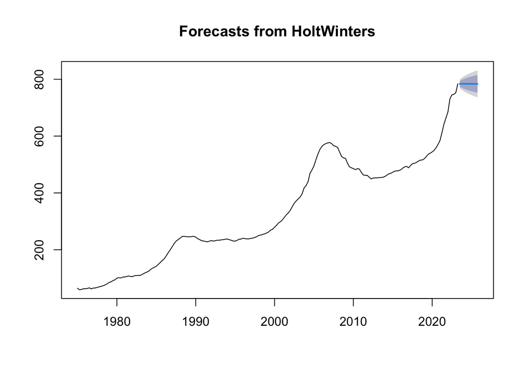

```r
SSE_Simple_forecast_4 <- forecast(SSE_Simple_4, h=10)
plot(SSE_Simple_forecast_4)
```

## Visualising All the Forecasts in a Single Graph

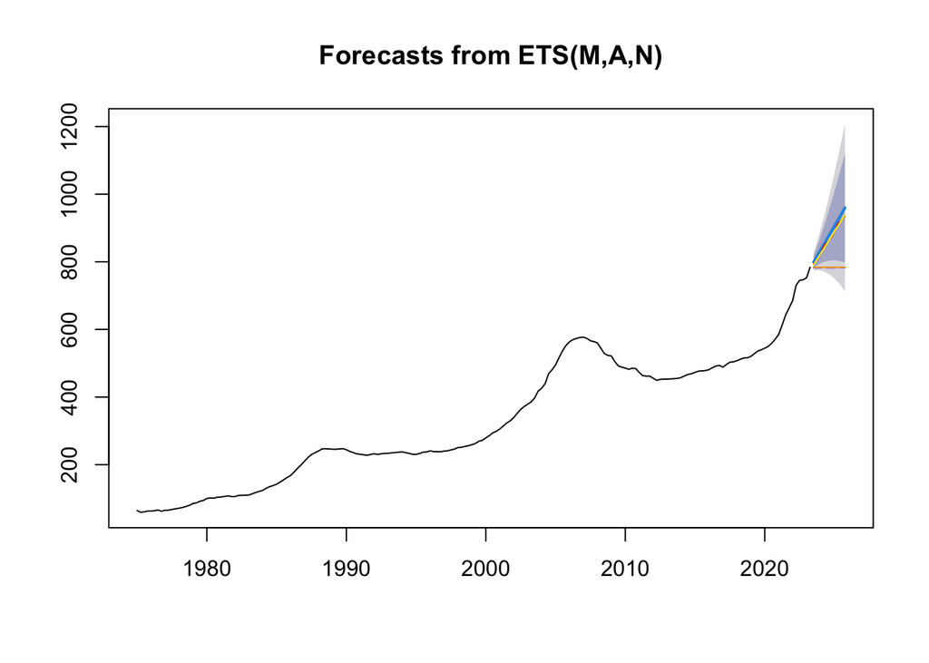

```r
# Combining Forecasts
plot(ets_forecast)
lines(HW_forecast$mean, col="red")
lines(SSE_Simple_forecast_1$mean, col="green")
lines(SSE_Simple_forecast_2$mean, col="blue")
lines(SSE_Simple_forecast_3$mean, col="yellow")
lines(SSE_Simple_forecast_4$mean, col="orange")
```

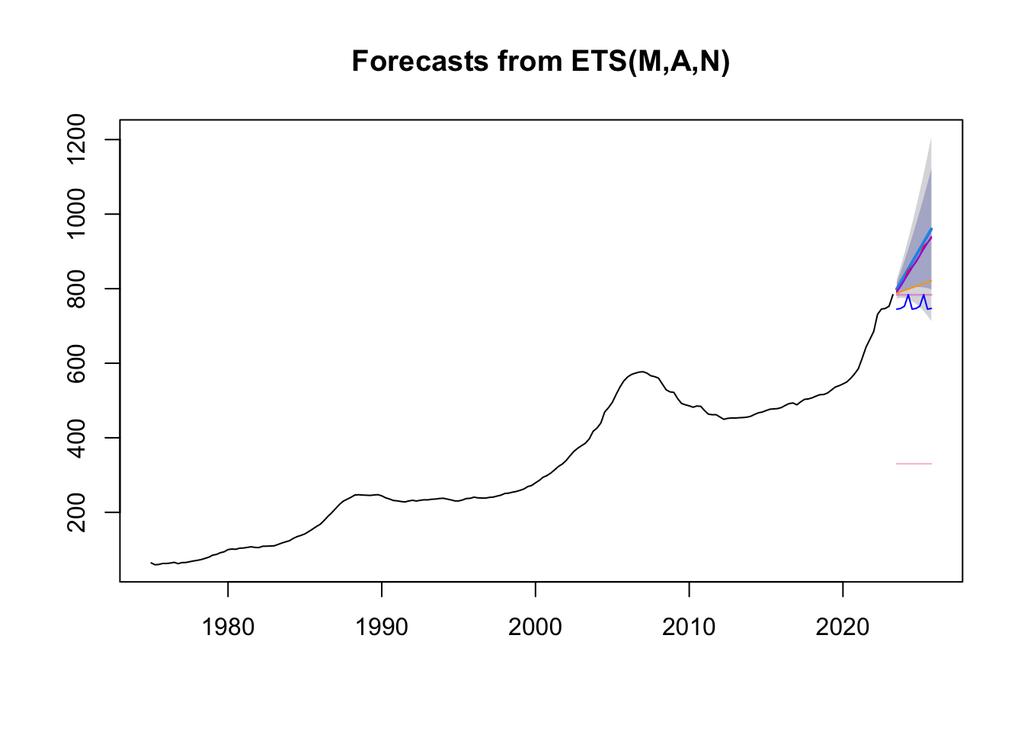

```r
# Combining All Forecasts with the original Time Series
plot(ets_forecast)
lines(HW_forecast$mean, col="red")
lines(SSE_Simple_forecast_1$mean, col="green")
lines(SSE_Simple_forecast_2$mean, col="violet")
lines(SSE_Simple_forecast_3$mean, col="purple")
lines(SSE_Simple_forecast_4$mean, col="yellow")
lines(mean_forecast$mean, col="pink")
lines(naive_forecast$mean,col="plum")
lines(rwf_forecast$mean,col="orange")
lines(snaive_forecast$mean,col="blue")
```

# Checking the Accuracy of our Models and Selecting the Best fit

```r
# Calculating Accuracy
accuracy(mean_forecast)
```

```
##                        ME     RMSE      MAE       MPE     MAPE     MASE
## Training set 1.875247e-14 182.5849 162.1937 -58.11511 88.20295 7.806663
##                   ACF1
## Training set 0.9775296
```

```r
accuracy(naive_forecast)
```

```
##                    ME     RMSE     MAE      MPE     MAPE      MASE      ACF1
## Training set 3.728601 8.539955 5.60456 1.264403 1.869083 0.2697571 0.7135887
```

```r
accuracy(rwf_forecast)
```

```
##                       ME     RMSE      MAE        MPE     MAPE      MASE
## Training set 7.93378e-15 7.682992 5.028623 -0.5002899 1.731568 0.2420363
##                   ACF1
## Training set 0.7135887
```

```r
accuracy(snaive_forecast)
```

```
##                    ME     RMSE      MAE      MPE     MAPE MASE      ACF1
## Training set 14.64495 30.15891 20.77632 4.919591 6.396315    1 0.9676102
```

```r
accuracy(ets_forecast)
```

```
##                     ME     RMSE      MAE       MPE     MAPE      MASE      ACF1
## Training set 0.2426135 5.235967 3.416886 0.1387439 1.148609 0.1644606 0.2265441
```

```r
accuracy(HW_forecast)
```

```
##                     ME     RMSE      MAE       MPE     MAPE      MASE      ACF1
## Training set 0.1991329 5.253751 3.647975 0.1056805 1.218338 0.1755833 0.2127471
```

```r
accuracy(SSE_Simple_forecast_1)
```

```
##                    ME     RMSE      MAE      MPE    MAPE      MASE      ACF1
## Training set 3.728769 8.540261 5.604789 1.264459 1.86915 0.2697682 0.7136114
```

```r
accuracy(SSE_Simple_forecast_2)
```

```
##                    ME     RMSE      MAE      MPE     MAPE      MASE      ACF1
## Training set 3.840475 8.729988 5.791254 1.329407 1.934961 0.2787431 0.6939226
```

```r
accuracy(SSE_Simple_forecast_3)
```

```
##                     ME     RMSE      MAE       MPE     MAPE      MASE      ACF1
## Training set 0.1774874 5.604529 3.659351 0.1522885 1.208618 0.1761309 0.1456659
```

```r
accuracy(SSE_Simple_forecast_4)
```

```
##                    ME     RMSE      MAE      MPE    MAPE      MASE      ACF1
## Training set 3.728769 8.540261 5.604789 1.264459 1.86915 0.2697682 0.7136114
```

## Accuracy Measures Calculated:

- Mean Error (ME)
- Root Mean Squared Error (RMSE)
- Mean Absolute Error (MAE)
- Mean Percentage Error (MPE)
- Mean Absolute Percentage Error (MAPE)
- Mean Absolute Scaled Error (MASE)
- Autocorrelation of errors at lag 1 (ACF1)

### Accuracy Measure Selected for Model Comparison:

#### Mean Absolute Percentage Error (MAPE)

The mean absolute percentage error (MAPE) measures the average of forecast errors in percentages. It’s a helpful accuracy metric to use because many people can understand forecast accuracy in terms of percentages.

For example, a MAPE of 3% means there was a 3% difference between the actual and projected data. Typically, a lower MAPE indicates a higher forecast accuracy.

### MAPE for different Models:

1. Mean Forecast: 88.20295
2. Naive Forecast: 1.869083
3. Random Walk Forecast: 1.731568
4. Simple Naive Forecast: 6.396315
5. Exponential smoothing Forecast: 1.148609
6. Holt-Winter Forecast: 1.218338
7. SSE Simple Forecast: 1.86915